# Biostat 203B Homework 2

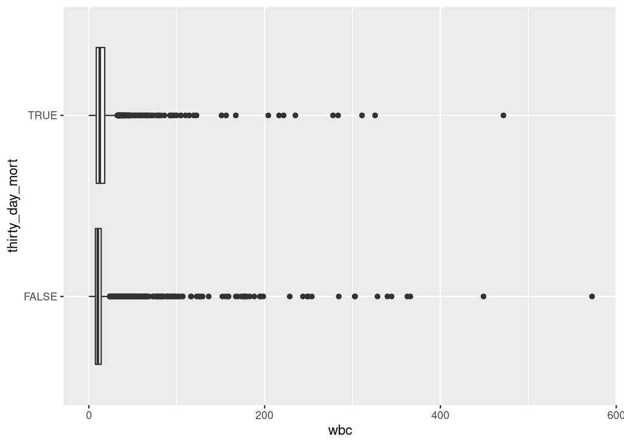

```r
ggplot(data = mimic_icu_cohort, mapping = aes(x = thirty_day_mort, y = wbc)) +
  geom_boxplot() +
  coord_flip()
```

**`thirty_day_mort` vs. first vital measurements:**

`heart_rate`:

```r
tapply(mimic_icu_cohort$heart_rate, mimic_icu_cohort$thirty_day_mort, summary)
```

```
## $`FALSE`
##    Min. 1st Qu.  Median    Mean 3rd Qu.    Max.    NA's
##    0.00   74.00   84.00   86.77   98.00  941.00       1
##
## $`TRUE`
##    Min. 1st Qu.  Median    Mean 3rd Qu.    Max.
##    0.00   77.00   92.00   93.37  108.00  191.00
```

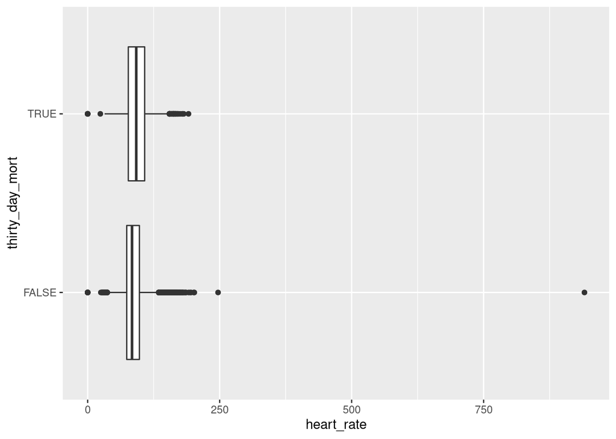

```r
ggplot(data = mimic_icu_cohort,
       mapping = aes(x = thirty_day_mort, y = heart_rate)) +
  geom_boxplot() +
  coord_flip()
```

`non_invasive_blood_pressure_systolic`:

```r
tapply(mimic_icu_cohort$non_invasive_blood_pressure_systolic,
       mimic_icu_cohort$thirty_day_mort, summary)
```

```
## $`FALSE`
##    Min. 1st Qu.  Median    Mean 3rd Qu.    Max.    NA's
##       0     107     122     124     139     259     263
##
## $`TRUE`
##    Min. 1st Qu.  Median    Mean 3rd Qu.    Max.    NA's
##     9.0   100.0   117.0   121.5   137.0 12262.0     249
```

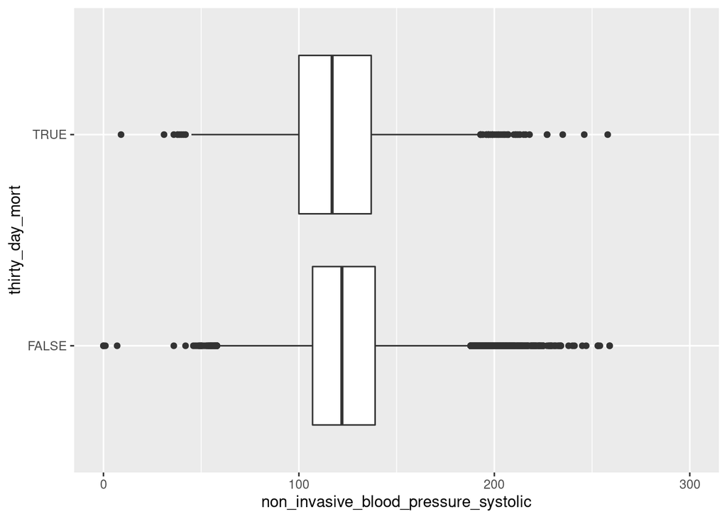

```r
ggplot(data = mimic_icu_cohort,
       mapping = aes(x = thirty_day_mort,
                     y = non_invasive_blood_pressure_systolic)) +
  geom_boxplot() +
  coord_flip() +
  scale_y_continuous(limits = c(0,300))
```

`non_invasive_blood_pressure_mean`:

```r
tapply(mimic_icu_cohort$non_invasive_blood_pressure_mean,
       mimic_icu_cohort$thirty_day_mort, summary)
```

```
## $`FALSE`
##      Min.   1st Qu.    Median      Mean   3rd Qu.      Max.      NA's
##      0.00     70.00     81.00     85.23     93.00 120130.00       286
##
## $`TRUE`
##     Min.  1st Qu.   Median     Mean  3rd Qu.     Max.     NA's
##     19.0     66.0     78.0    106.9     93.0 140119.0      247
```

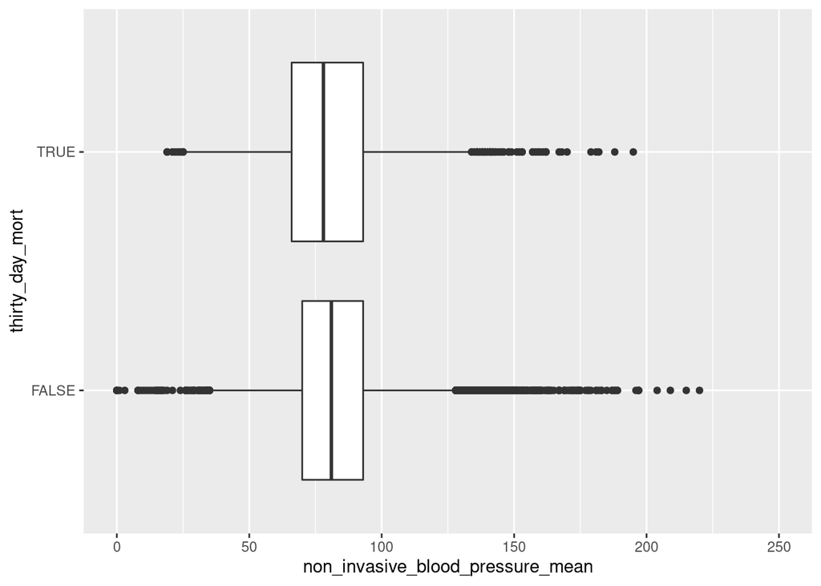

```r
ggplot(data = mimic_icu_cohort,
       mapping = aes(x = thirty_day_mort,
                     y = non_invasive_blood_pressure_mean)) +
  geom_boxplot() +
  coord_flip() +
  scale_y_continuous(limits = c(0,250))
```

`respiratory_rate`:

```r
tapply(mimic_icu_cohort$respiratory_rate,
       mimic_icu_cohort$thirty_day_mort, summary)
```

```
## $`FALSE`
##    Min. 1st Qu.  Median    Mean 3rd Qu.    Max.    NA's
##    0.00   14.00   18.00   18.41   22.00  180.00      31
##
## $`TRUE`
##    Min. 1st Qu.  Median    Mean 3rd Qu.    Max.    NA's
##    0.00   16.00   20.00   21.11   25.00  115.00       6
```

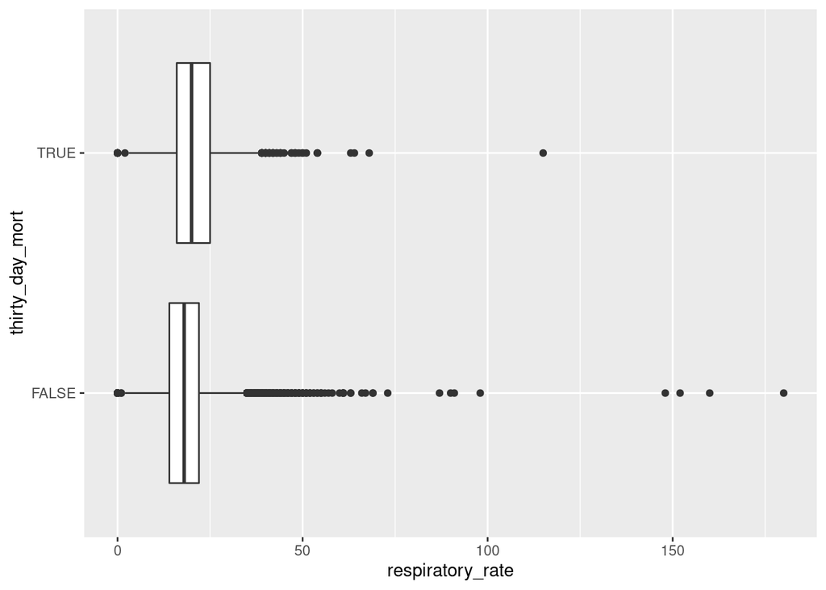

```r
ggplot(data = mimic_icu_cohort,
       mapping = aes(x = thirty_day_mort,
                     y = respiratory_rate)) +
  geom_boxplot() +
  coord_flip()
```

`temperature_fahrenheit`:

```r
tapply(mimic_icu_cohort$temperature_fahrenheit,
       mimic_icu_cohort$thirty_day_mort, summary)
```

```
## $`FALSE`
##    Min. 1st Qu.  Median    Mean 3rd Qu.    Max.    NA's
##    0.00   97.60   98.20   98.09   98.70  106.00     356
##
## $`TRUE`
##    Min. 1st Qu.  Median    Mean 3rd Qu.    Max.    NA's
##    0.00   97.40   98.00   97.48   98.70  105.80     463
```

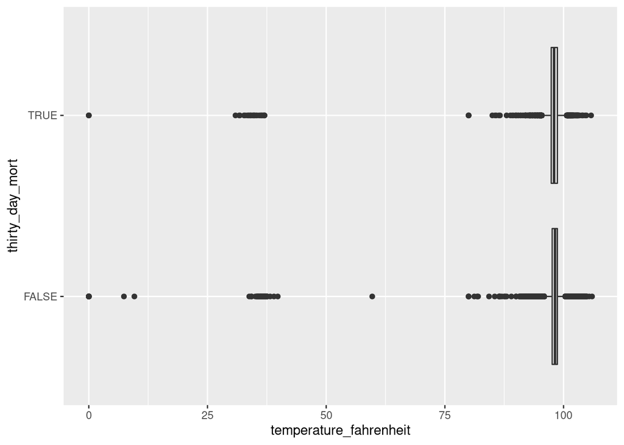

```r
ggplot(data = mimic_icu_cohort,
       mapping = aes(x = thirty_day_mort,
                     y = temperature_fahrenheit)) +
  geom_boxplot() +
  coord_flip()
```

**Note:** Apparently, the data-set needs to be further filtered: some observations were so large/small that they do not even make sense to people without in-depth knowledge in health sciences. For example, the variable `non_invasive_blood_pressure_systolic` has a minimum value of 9.0 and maximum value of 12262.0 for the “TRUE” group of `thirty_day_mort` (subjects who died within 30 days of hospital admission). Same for `heart_rate`: the maximum value of the “FALSE” group of `thirty_day_mort` is 941.0, which should definitely be treated as an error and discarded. In conclusion, the summary statistics of the data-set `mimic_icu_cohort` is a helpful tool enabling us to check the validity of data imported. The abnormal data should be further looked into and removed if necessary.

**`thirty_day_mort` vs first ICU unit:**

`admission_type`

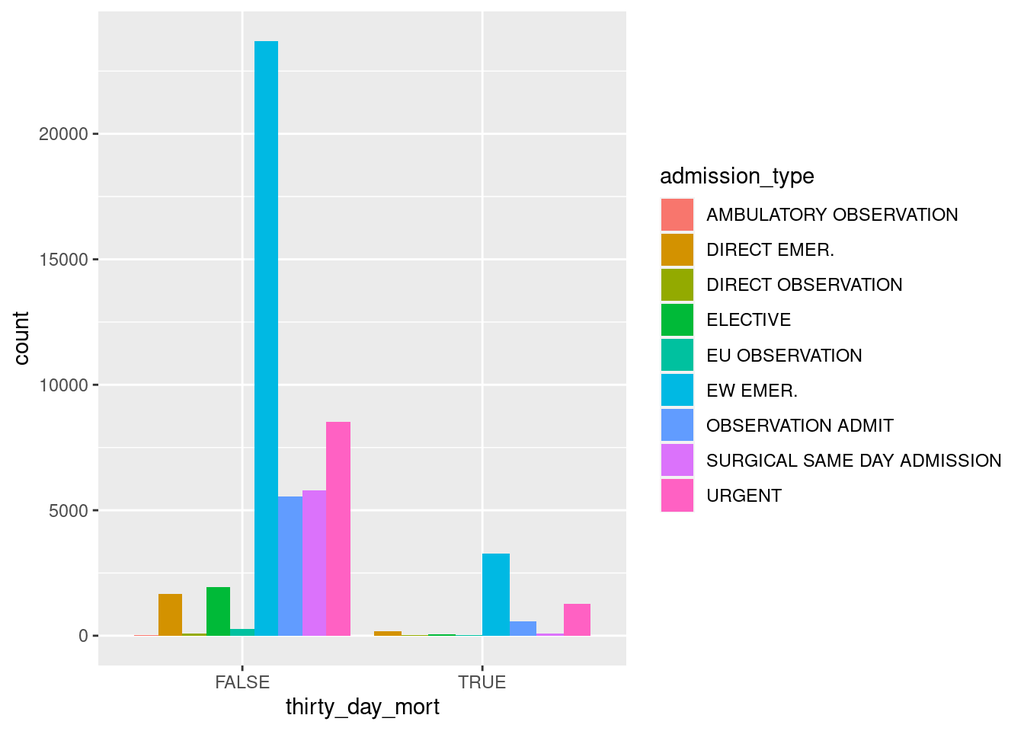

```r
ggplot(data = mimic_icu_cohort) +
  geom_bar(mapping = aes(x = thirty_day_mort,
                         fill = admission_type), position = "dodge")
```

`admission_location`

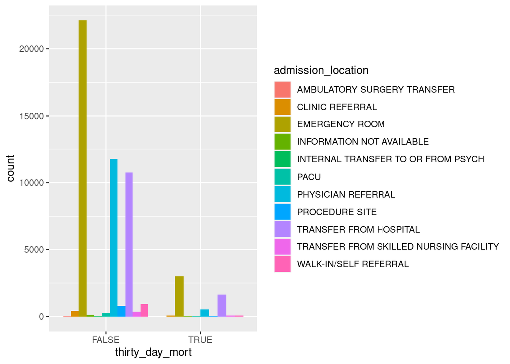

```r
ggplot(data = mimic_icu_cohort) +
  geom_bar(mapping = aes(x = thirty_day_mort,
                         fill = admission_location), position = "dodge")
```

`discharge_location`

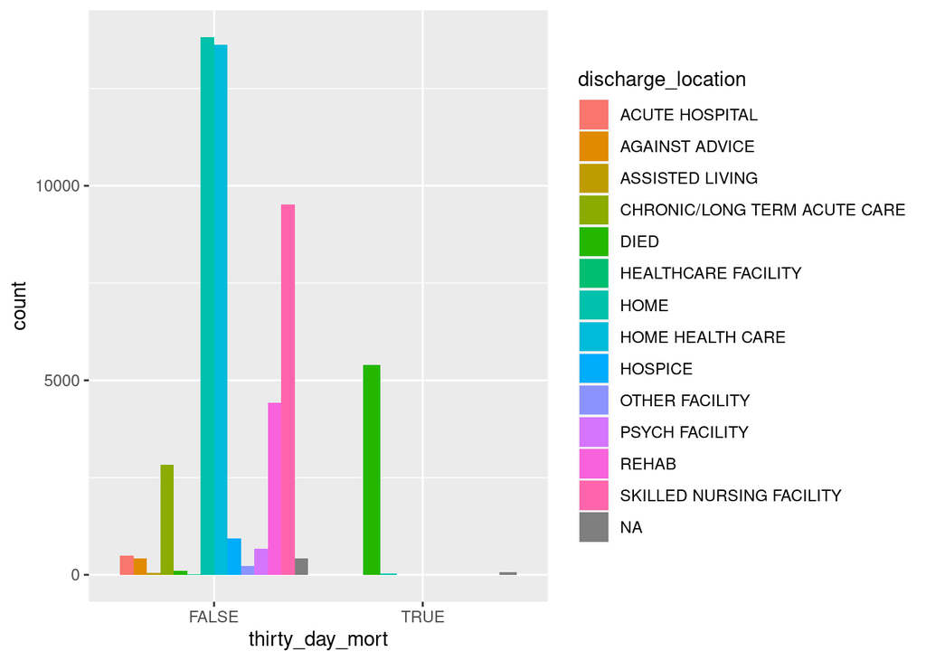

```r
ggplot(data = mimic_icu_cohort) +
  geom_bar(mapping = aes(x = thirty_day_mort,
                         fill = discharge_location), position = "dodge")
```

`intime`

```r
tapply(mimic_icu_cohort$intime,
       mimic_icu_cohort$thirty_day_mort, summary)
```

```
## $`FALSE`
##                  Min.               1st Qu.                Median
## "2110-01-11 10:16:06" "2132-11-19 12:56:40" "2152-10-26 13:39:32"
##                  Mean               3rd Qu.                  Max.
## "2152-11-15 22:51:00" "2172-11-17 23:19:36" "2211-05-01 06:59:19"
##
## $`TRUE`
##                  Min.               1st Qu.                Median
## "2110-01-18 14:46:27" "2132-06-30 00:51:00" "2152-02-19 18:46:00"
##                  Mean               3rd Qu.                  Max.
## "2152-05-18 13:46:24" "2172-05-03 20:02:47" "2211-01-14 14:37:00"
```

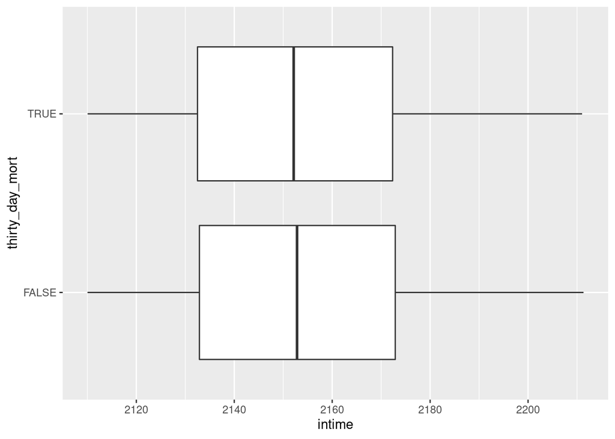

```r
ggplot(data = mimic_icu_cohort,
       mapping = aes(x = thirty_day_mort,
                     y = intime)) +
  geom_boxplot() +
  coord_flip()
```

`outtime`

```r
tapply(mimic_icu_cohort$outtime,
       mimic_icu_cohort$thirty_day_mort, summary)
```

```
## $`FALSE`
##                  Min.               1st Qu.                Median
## "2110-01-12 17:17:47" "2132-11-23 22:45:49" "2152-10-29 20:13:34"
##                  Mean               3rd Qu.                  Max.
## "2152-11-19 03:35:12" "2172-11-19 19:53:47" "2211-05-10 22:51:06"
##
## $`TRUE`
##                  Min.               1st Qu.                Median
## "2110-01-25 12:42:11" "2132-07-02 12:05:09" "2152-02-22 18:25:50"
##                  Mean               3rd Qu.                  Max.
## "2152-05-23 08:55:47" "2172-05-05 04:41:00" "2211-01-17 15:23:45"
```

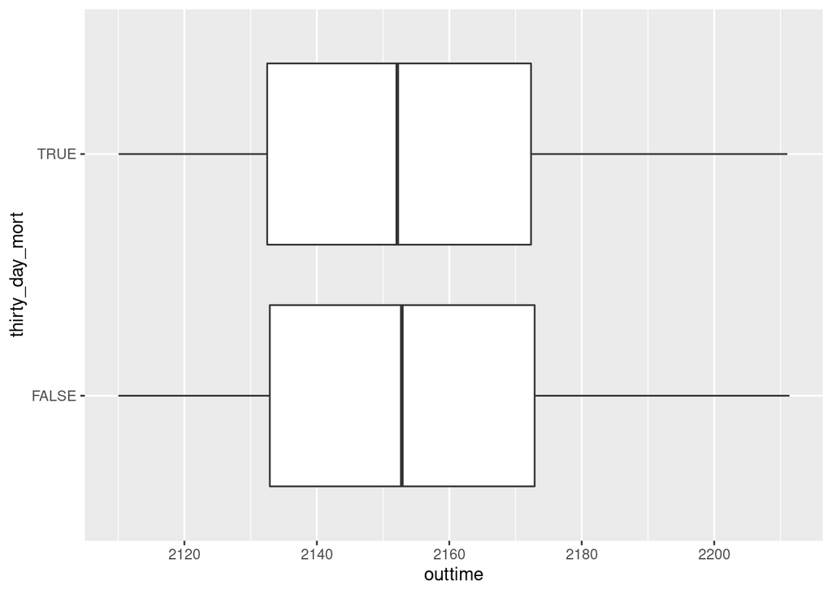

```r
ggplot(data = mimic_icu_cohort,
       mapping = aes(x = thirty_day_mort,
                     y = outtime)) +
  geom_boxplot() +
  coord_flip()
```

`los` (length of stay, in days)

```r
tapply(mimic_icu_cohort$los,
       mimic_icu_cohort$thirty_day_mort, summary)
```

```
## $`FALSE`
##      Min.   1st Qu.    Median      Mean   3rd Qu.      Max.
##   0.00125   1.08558   1.83866   3.19736   3.29277 110.23228
##
## $`TRUE`
##     Min.  1st Qu.   Median     Mean  3rd Qu.     Max.
##  0.01186  1.08906  2.60449  4.79819  6.01043 77.74071
```

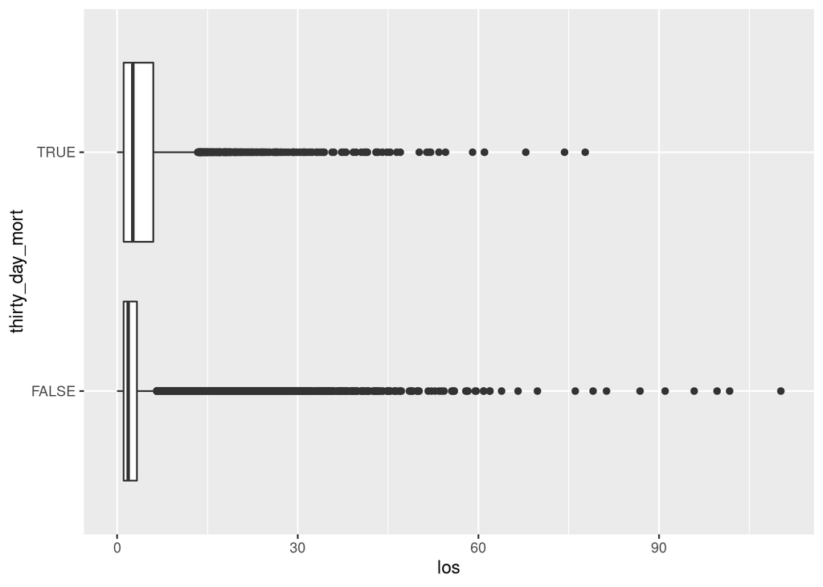

```r
ggplot(data = mimic_icu_cohort,
       mapping = aes(x = thirty_day_mort,
                     y = los)) +
  geom_boxplot() +
  coord_flip()
```

`deathtime`

```r
tapply(mimic_icu_cohort$deathtime,
       mimic_icu_cohort$thirty_day_mort, summary)
```

```
## $`FALSE`
##    Min. 1st Qu.  Median    Mean 3rd Qu.    Max.    NA's
##      NA      NA      NA      NA      NA      NA "47558"
##
## $`TRUE`
##                  Min.               1st Qu.                Median
## "2110-01-25 09:40:00" "2132-07-10 07:00:00" "2152-02-27 00:01:00"
##                  Mean               3rd Qu.                  Max.
## "2152-05-26 08:36:13" "2172-05-05 03:35:00" "2211-01-17 12:34:00"
```

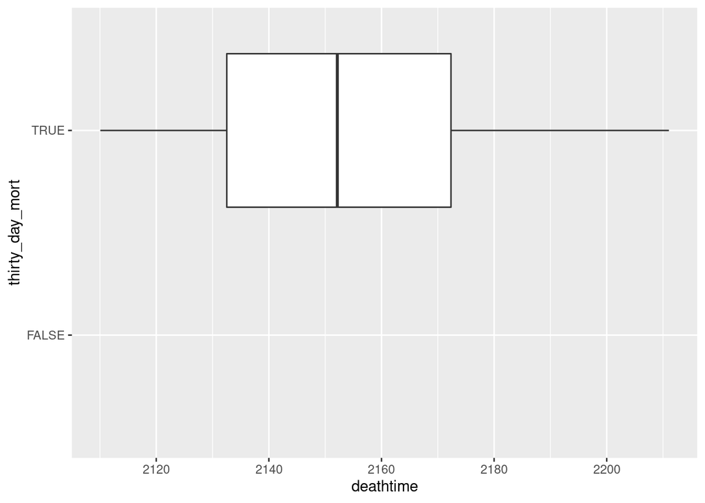

```r
ggplot(data = mimic_icu_cohort,
       mapping = aes(x = thirty_day_mort,
                     y = deathtime)) +
  geom_boxplot() +
  coord_flip()
```

**Note**: since the subjects in “FALSE” group of `thirty_day_mort` did not die within 30 days of hospitalization, the summary statistics are all not applicable.

`admittime` (admission time)

```r
tapply(mimic_icu_cohort$admittime,
       mimic_icu_cohort$thirty_day_mort, summary)
```

```
## $`FALSE`
##                  Min.               1st Qu.                Median
## "2110-01-11 10:14:00" "2132-11-18 06:54:00" "2152-10-26 10:45:00"
##                  Mean               3rd Qu.                  Max.
## "2152-11-14 23:54:49" "2172-11-17 21:26:00" "2211-05-01 06:57:00"
##
## $`TRUE`
##                  Min.               1st Qu.                Median
## "2110-01-18 14:46:00" "2132-06-29 23:23:00" "2152-02-17 12:39:00"
##                  Mean               3rd Qu.                  Max.
## "2152-05-16 19:21:48" "2172-05-03 19:25:00" "2211-01-14 13:14:00"
```

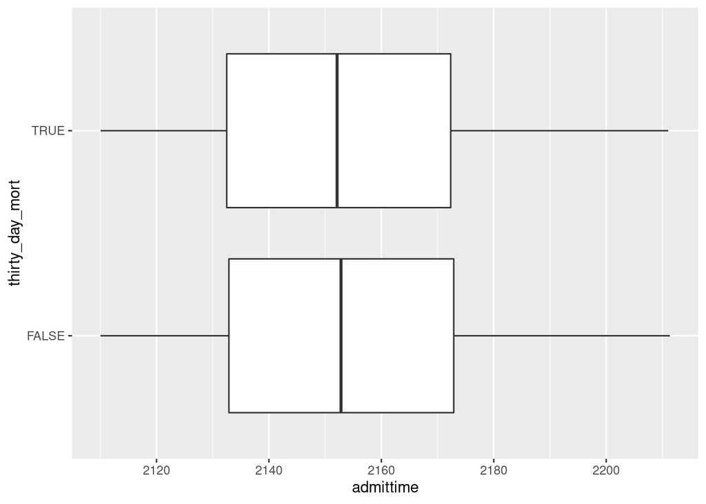

```r
ggplot(data = mimic_icu_cohort,
       mapping = aes(x = thirty_day_mort,
                     y = admittime)) +
  geom_boxplot() +
  coord_flip()
```

`dischtime` (discharged time)

```r
tapply(mimic_icu_cohort$dischtime,
       mimic_icu_cohort$thirty_day_mort, summary)
```

```
## $`FALSE`
##                  Min.               1st Qu.                Median
## "2110-01-15 17:31:00" "2132-11-28 10:01:15" "2152-11-05 05:19:00"
##                  Mean               3rd Qu.                  Max.
## "2152-11-24 09:55:47" "2172-11-25 08:49:30" "2211-05-12 17:54:00"
##
## $`TRUE`
##                  Min.               1st Qu.                Median
## "2110-01-25 09:40:00" "2132-07-10 07:00:00" "2152-02-27 00:01:00"
##                  Mean               3rd Qu.                  Max.
## "2152-05-26 07:28:15" "2172-05-05 03:35:00" "2211-01-17 12:34:00"
```

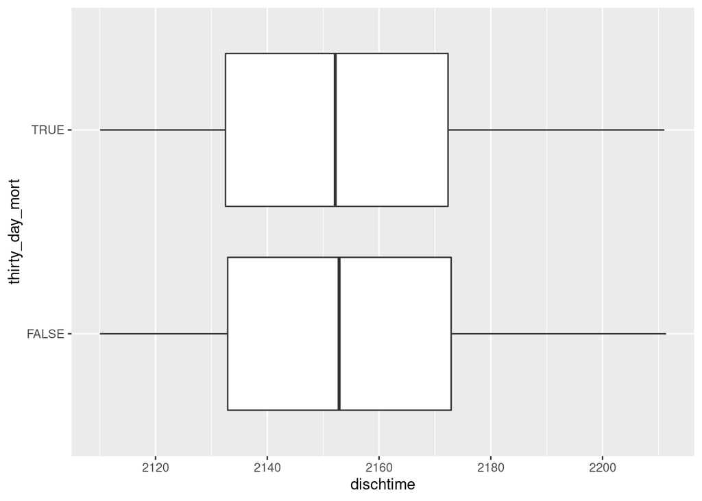

```r
ggplot(data = mimic_icu_cohort,
       mapping = aes(x = thirty_day_mort,
                     y = dischtime)) +
  geom_boxplot() +
  coord_flip()
```

`age_adm` (age at hospital admission, in years)

```r
tapply(mimic_icu_cohort$age_adm,
       mimic_icu_cohort$thirty_day_mort, summary)
```

```
## $`FALSE`
##    Min. 1st Qu.  Median    Mean 3rd Qu.    Max.
##    19.0    53.0    66.0    63.8    77.0   102.0
##
## $`TRUE`
##    Min. 1st Qu.  Median    Mean 3rd Qu.    Max.
##   19.00   61.00   73.00   70.94   83.00  100.00
```

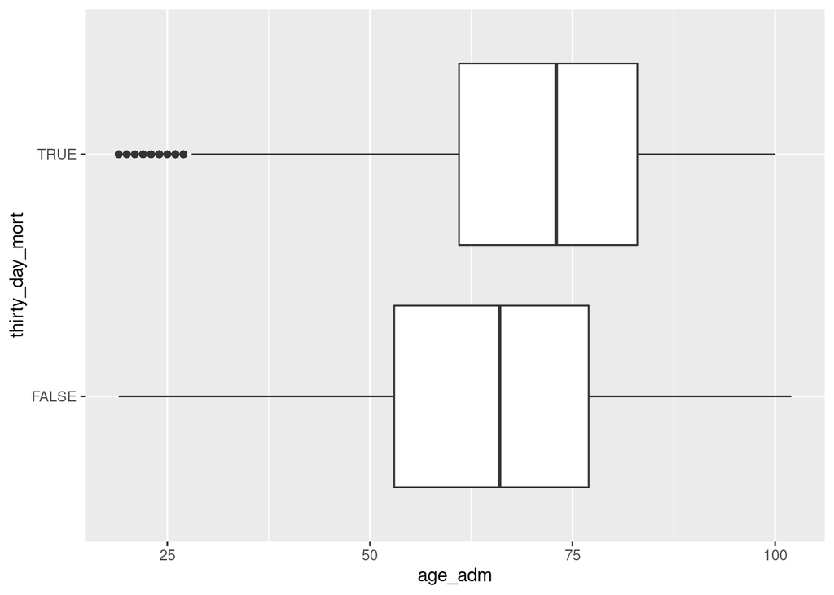

```r
ggplot(data = mimic_icu_cohort,
       mapping = aes(x = thirty_day_mort,
                     y = age_adm)) +
  geom_boxplot() +
  coord_flip()
```